# TRABALHO FINAL: ANÁLISE DE REGRESSÃO UTILIZANDO BASE DE PREÇOS DE IMÓVEIS DE SÃO PAULO

ADRIANO PIRES, BEATRIZ REIS, FERNANDA ABREU

OURO PRETO, MG 2022

# 1 Introdução

Para realização deste trabalho, iremos utilizar um banco de dados no qual os dados mobiliários da cidade de São Paulo em diversas variáveis. Os dados possuem milhares de observações, porém selecionamos apenas algumas das variáveis (as qual nos interessa) para montar o modelo, inicialmente usamos as seguintes variáveis:

- **Logradouro:**lugar onde está o imóvel (rua,hortos,passeios);
- **Bairro:**bairro de São Paulo que se localiza o imóvel;
- **Cep:** código de endereçameno postal;
- **Tipo de Imóvel:**se referindo a apartamento,casas, etc;
- **Area útil:**área em metros² do imóvel;
- **Banheiros:**quantidade de banheiros no imóvel;
- **Vagas garagem:**quantidade de vagas na garagem;
- **Preço venda:**preço de venda do imóvel;
- **Preço aluguel:**preço do aluguel do imóvel;

Além dessas variáveis, há diversas outras porém não muito úteis para tal análise. **Pela quantidade e variedade dos dados, escolhermos fazer uma análise apenas dos apartamentos para alugar, desta forma, usaremos**:

1. A variável resposta: *preço do aluguel*
2. As variáveis explicativas: área útil,banheiros,suites,quartos,vagas de garagem,preço do aluguel e Zonas(a qual criaremos utilizando o Cep e Bairros)

Os dados analisados estão disponíveis para download no [Kaggle](https://www.kaggle.com/datasets/ex0ticone/house-prices-of-sao-paulo-city)

# 2 Manipulação dos dados

Para realização deste trabalho, usamos os seguintes pacotes:

```r
library(dplyr)
library(car)
library(rstatix)
library(emmeans)
library(ggplot2)
library(knitr)
library(kableExtra)
library(htmltools)
library(dplyr)
library(tidyverse)
library(GGally)
library(corrr)
library(nortest)
library(readxl)
library(cowplot)
```

## 2.1 Limpando os dados

Realizamos a limpeza dos dados principalmente usando o pacote *Dplyr* o qual ajudou muito a deixar mais claro as variáveis para o uso no modelo.

```r
BaseOriginal<-read_excel("housing_sp_city1.xls")
BaseTop<-BaseOriginal %>% select(preco_aluguel,bairro,cep,tipo_imovel,area_util,banheiros,suites,quartos,vagas_garagem,periodicidade)
BaseTop<-BaseTop %>% filter(periodicidade=="MONTHLY",tipo_imovel=="Apartamento")
kable(head(BaseTop,10), col.names = c("Preço Aluguel", "Bairro", "Cep", "Tipo de imóvel","Área(m²)","Banheiros","Suítes","Quatos","Vagas Garagem","Periodicidade")) %>%
  kable_styling(full_width = F, bootstrap_options = c("striped", "hover", "condensed", "responsive"))
```

| Preço Aluguel | Bairro | Cep | Tipo de imóvel | Área(m²) | Banheiros | Suítes | Quatos | Vagas Garagem | Periodicidade |
| --- | --- | --- | --- | --- | --- | --- | --- | --- | --- |
| 12299 | Indianópolis | 4081010 | Apartamento | 240 | 3 | 2 | 4 | 3 | MONTHLY |
| 1941 | Cidade São Francisco | 5351025 | Apartamento | 72 | 2 | 1 | 3 | 2 | MONTHLY |
| 0 | Parque das Paineiras | 3692060 | Apartamento | 35 | 1 | 0 | 2 | 0 | MONTHLY |
| NA | Perdizes | 5018011 | Apartamento | 123 | 3 | 1 | 3 | 2 | MONTHLY |
| 0 | Artur Alvim | 3692060 | Apartamento | 42 | 1 | 0 | 2 | 0 | MONTHLY |
| 0 | Jardim Umarizal | 5756240 | Apartamento | 84 | 1 | 0 | 2 | 1 | MONTHLY |
| 2485 | Pinheiros | 3178200 | Apartamento | 30 | 1 | 1 | 1 | 0 | MONTHLY |
| 3290 | Penha | 3632020 | Apartamento | 154 | 5 | 3 | 3 | 3 | MONTHLY |
| 1014 | Vila Maria | 2127001 | Apartamento | 64 | 1 | 0 | 2 | 1 | MONTHLY |
| 5950 | Vila Romana | 5051030 | Apartamento | 180 | 5 | 2 | 4 | 3 | MONTHLY |

Com a tabela acima, temos uma visão geral do banco, porém uma série de mudanças vão acontecer agora para ajudar a deixar o banco mais limpo possível para usarmos os dados no **ajuste**, um adendo é que, por causa de alguns Ceps mal formatados ou faltantes, fizemos um trabalho manual pelo excel para corrigir os números e também achar Ceps em brancos (usamos os logradouros e bairros), algumas das manipulações dos dados apresentamos abaixo:

```r
BaseTop=BaseTop %>% filter(preco_aluguel!=0)
BaseTop = BaseTop %>% mutate_at(vars(cep,area_util,banheiros,suites,quartos,vagas_garagem,preco_aluguel),parse_number)#passando os valores <chr> para numérico
BaseTop=BaseTop %>% mutate(Zonas=case_when(cep>=1000000 & cep<=1599000 ~ "Centro",
                                      cep>=2000000 & cep<=2999000 ~ "Norte",
                                      cep>=3000000 & cep<=3999000 ~ "Leste",
                                      cep>=8000000 & cep<=8499000 ~ "Leste",
                                      cep>=4000000 & cep<=4999000 ~ "Sul",
                                      cep>=5000000 & cep<=5999000 ~ "Oeste"))#Categorizando os ceps pelas Zonas da cidade de São paulo
BaseTop=BaseTop %>% select(preco_aluguel,area_util,banheiros,suites,quartos,vagas_garagem,Zonas)#Retirando as variáveis agora desnecessárias para o modelo
BaseTop=na.omit(BaseTop)#Omitindo os dados NA
BaseTop=BaseTop %>% mutate(Z1=case_when(Zonas=="Centro" ~ 1,
                                    Zonas!="Centro" ~ 0),
                       Z2=case_when(Zonas=="Leste" ~ 1,
                                    Zonas!="Leste" ~ 0),
                       Z3=case_when(Zonas=="Sul" ~ 1,
                                    Zonas!="Sul" ~ 0),
                       Z4=case_when(Zonas=="Oeste" ~ 1,
                                    Zonas!="Oeste" ~ 0),
                       Z5=case_when(Zonas=="Norte" ~ 1,
                                    Zonas!="Norte" ~ 0))#Separar as Zonas em dummy
```

## 2.2 Visualizando o Banco Final

Por fim, após essa limpeza nos dados, temos nossa Base final já tratada abaixo:

```r
kable(head(BaseTop,20), col.names = c("Preço Aluguel","Área(m²)","Banheiros","Suítes","Quartos","Vagas Garagem","Zonas","Z1","Z2","Z3","Z4","Z5")) %>%
  kable_styling(full_width = F, bootstrap_options = c("striped", "hover", "condensed", "responsive"))
```

[output not shown]

O banco contém 4528 observações, as quais vamos agora usar para fazer algumas **análises descritivas**.

# 3 Resultados

## 3.1 Análise descritiva

```r
BaseTop=BaseTop %>% select(preco_aluguel,area_util,banheiros,suites,quartos,vagas_garagem,Zonas,Z1,Z2,Z3,Z4,Z5)
```

Vamos plotar dois gráficos de correlação para vermos quais as variáveis mais correlacionadas, para entendermos um pouco melhor como ficará o modelo.

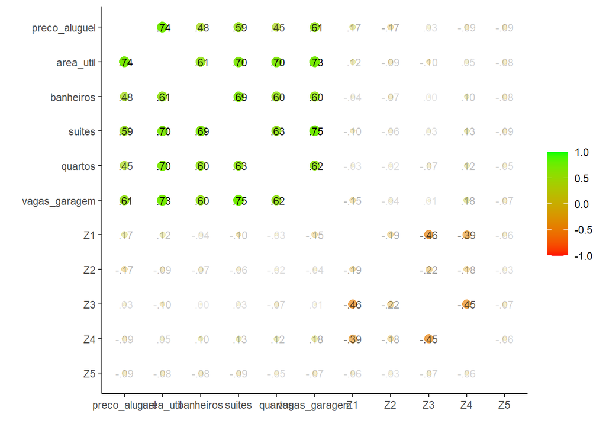

```r
BaseTop %>%
  correlate(quiet = TRUE) %>%
  rplot(shape=20,colors=c("red","green"),print_cor = TRUE)#Uma mera impressão inicial das correlações usando pacote Corrr
```

Agora vamos visualizar essa correlação novamente, porém de uma forma diferente, que passa a mesma informação mais de forma mais simples:

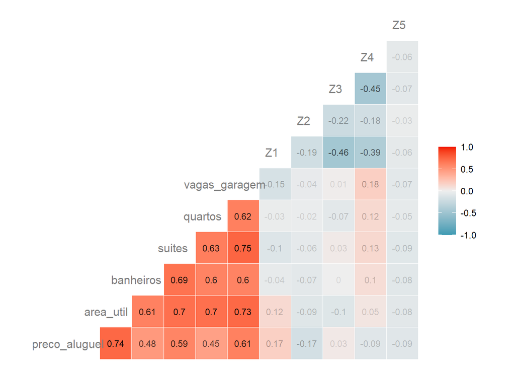

```r
ggcorr(BaseTop,label=T,label_size = 3, label_round = 2, label_alpha = TRUE,
       hjust = 0.72, size = 4, color = "grey50", layout.exp = 1)#usando pacote GGally temos uma melhor forma de visualizar as correlações, nessa visualização em modo triangulo
```

A partir dos gráficos, vamos analisar as variáveis mais correlacionadas.  
Vemos que , **area**, **suites**, **quartos** e **vagas garagem** se relacionam bem com **preço de aluguel**, todavia também esperariamos uma boa correlação de algumas das Zonas, vamos ver o que podemos fazer.  
Primeiramente vamos plotar o histograma com os preços dos imóveis com área maior que 157m²(valor da média das áreas), e acima que esse valor, para termos uma base.

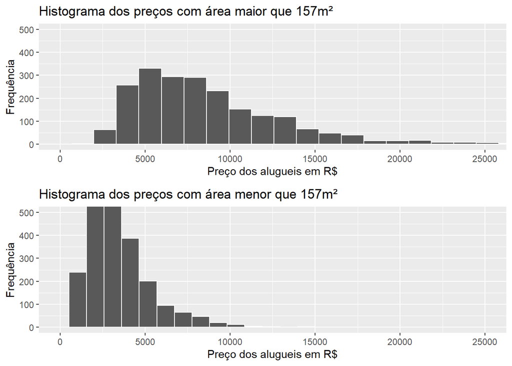

```r
h1=BaseTop %>% filter(area_util>=157)
h2=BaseTop %>% filter(area_util<157)
plot_grid(ggplot(h1, aes(x = preco_aluguel)) +
            geom_histogram(color = "white",bins = 45) +
            coord_cartesian(xlim = c(0,25000), ylim = c(0, 500))+
            labs(title = "Histograma dos preços com área maior que 157m²")+
            xlab("Preço dos alugueis em R$") +
            ylab("Frequência"),
          ggplot(h2, aes(x = preco_aluguel)) +
            geom_histogram(color = "white",bins = 45) +
            coord_cartesian(xlim = c(0,25000), ylim = c(0, 500))+
            labs(title = "Histograma dos preços com área menor que 157m²")+
            xlab("Preço dos alugueis em R$") +
            ylab("Frequência"),ncol=1)
```

Como visto no gráfico, as casas com maiores áreas tem preços maiores, podemos afirmar portanto que o aluguel está relacionado a área do imóvel.

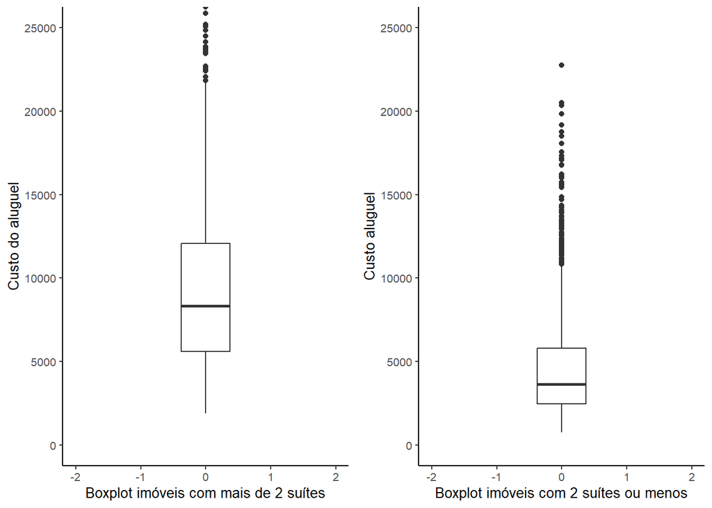

```r
h1=BaseTop %>% filter(suites<=2)
h2=BaseTop %>% filter(suites>2)
plot_grid(ggplot(h2, aes(y = preco_aluguel)) +
            geom_boxplot(show.legend = T, alpha = 1) +
            theme_classic(base_size = 10) +
            coord_cartesian(xlim = c(-2,2), ylim = c(0, 25000))+
            xlab("Boxplot imóveis com mais de 2 suítes") +
            ylab("Custo do aluguel"),
          ggplot(h1, aes(y = preco_aluguel)) +
            geom_boxplot(show.legend = T, alpha = 12) +
            coord_cartesian(xlim = c(-2,2), ylim = c(0, 25000))+
            theme_classic(base_size = 10) +
            xlab("Boxplot imóveis com 2 suítes ou menos") +
            ylab("Custo aluguel"))
```

Fizemos o mesmo para as outras variáveis citadas acima e apresentaram resumidamente a mesma performance de correlação, portanto vamos entrar agora na **variável Zonas**, a qual dividimos cada um em variáveis **Dummys** porém o gráfico abaixo mostrando a **correlação do custo com a área**, por zona, já demonstra bem uma interação entre as variáveis

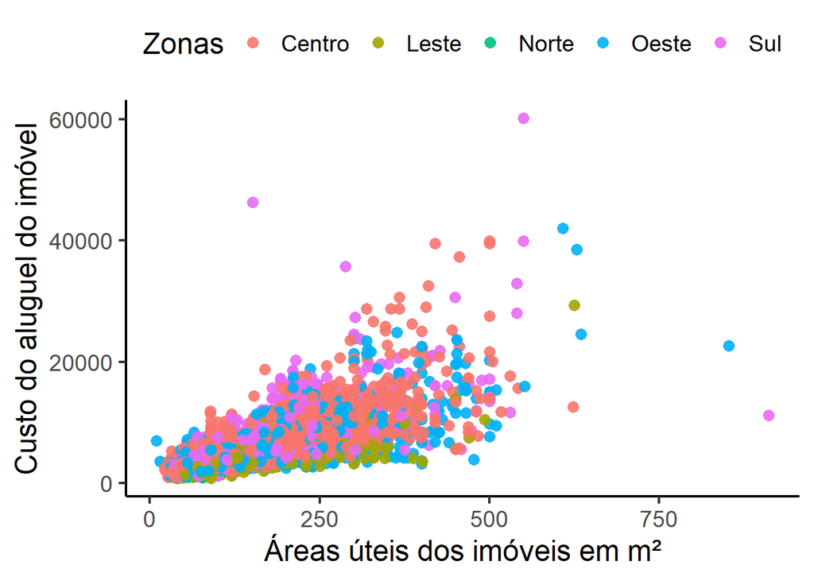

```r
ggplot(BaseTop, aes(y = preco_aluguel, x = area_util
                  ,color=Zonas )) +
  geom_point(size=3,alpha=0.9)+
  theme_classic(base_size = 18) +
  theme(legend.position = "top") +
  xlab("Áreas úteis dos imóveis em m²") +
  ylab("Custo do aluguel do imóvel")
```

Vemos os dados de 3 Regiões (Z1,Z3,Z4) acima que as outras, sugerindo assim uma ideia que quanto mais alto o aluguel, possivelmente será um imóvel em uma dessas regiões.

É interessante também mostrarmos o Box-plot por Zonas relacionado ao custo.

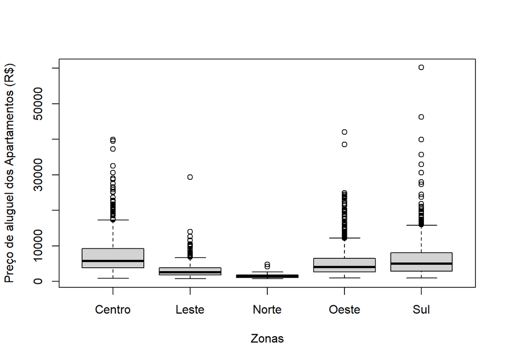

```r
# Edita níveis do fator.
BaseTop$Zonas <- factor(BaseTop$Zonas)
boxplot(BaseTop$preco_aluguel ~ BaseTop$Zonas,
        data = dados,
        xlab = "Zonas",
        ylab = "Preço de aluguel dos Apartamentos (R$)")
```

Infelizmente a base contou com poucos dados das Zonas do Norte e Leste, sendo assim, por mais que sugira uma leve diferença para maiores custos nas outras Zonas, não podemos indicar com certeza esse fato.

## 3.2 Ausência de *outliers*

[figure not shown]

```r
boxplot(dados$Memoria ~ dados$Genero:dados$Alcool, ylab = "Memória", xlab = "Grupo",
        names = c("F N", "M N", "F 2C", "M 2C", "F 4C", "M 4C"))
```

Os gráficos mostram que não há *outliers* nos grupos analisados.

## 3.3 Homogeneidade de variâncias

Outro pressuposto da ANOVA é que os grupos apresentem variâncias homogêneas. Esse pressuposto será analisado aqui pelo teste de Levene.

```r
leveneTest(Memoria ~ Genero*Alcool, dados, center = mean)
```

```
## Levene's Test for Homogeneity of Variance (center = mean)
##       Df F value Pr(>F)
## group  5  1.5268 0.2021
##       42
```

Os resultados indicam que as variâncias são homogêneas, uma vez que o teste de Levene apresentou p superior a 0,05.

# 4 Realização do teste de ANOVA de duas vias

## 4.1 Trocando o tipo de contraste

Para essa análise, será utilizado o contraste “soma”.

```r
options(contrasts = c("contr.sum", "contr.poly"))
```

## 4.2 Criação do modelo de ANOVA

Será criado um modelo de ANOVA usando a função `aov`. O modelo escolhido é um modelo fatorial completo, que inclui os efeitos principais das variáveis independentes “Gênero” e “Álcool” bem como a interação entre elas.

```r
mod.ANOVA <- aov(Memoria ~ Genero*Alcool, dados)
```

## 4.3 Análise dos resultados do modelo

Para avaliar a significância das variáveis independentes e da sua interação, será utilizada a soma de quadrados do tipo III. Mais informações sobre os tipos de soma dos quadrados podem ser encontradas no livro “Discovering Statistics Using R” [^1].

```r
Anova(mod.ANOVA, type = 'III')
```

```
## Anova Table (Type III tests)
##
## Response: Memoria
##               Sum Sq Df   F value    Pr(>F)
## (Intercept)   163333  1 1967.0251 < 2.2e-16 ***
## Genero           169  1    2.0323    0.1614
## Alcool          3332  2   20.0654 7.649e-07 ***
## Genero:Alcool   1978  2   11.9113 7.987e-05 ***
## Residuals       3488 42
## ---
## Signif. codes:  0 '***' 0.001 '**' 0.01 '*' 0.05 '.' 0.1 ' ' 1
```

O resultado nos indica que há efeito do “Álcool” [F(2,42) = 20,07; p < 0,001] e da interação entre “Gênero” e “Álcool” [F(2,42) = 11,91; p < 0,001] sobre a memória. Dado que existe interação, os efeitos principais não devem ser interpretados. Para investigar melhor essa interação, será feito um gráfico de linhas.

## 4.4 Análise da interação entre “Gênero” e “Álcool” sobre a “Memória”

```
## No summary function supplied, defaulting to `mean_se()`
```

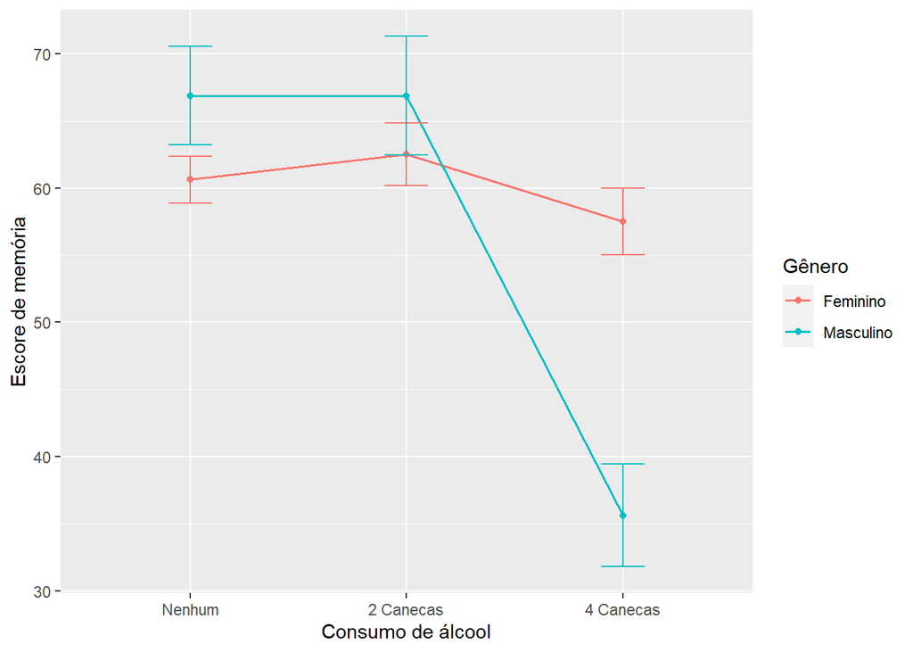

```r
ggplot(dados, aes(x = Alcool, y = Memoria, group = Genero, color = Genero)) +
  geom_line(stat = "summary", fun.data = "mean_se", size = 0.6) +
  geom_point(stat = "summary", fun.y = "mean") +
  geom_errorbar(stat = "summary", fun.data = "mean_se", width = 0.2) +
  ylab("Escore de memória") +
  xlab("Consumo de álcool") +
  labs(color = "Gênero")
```

Pelo gráfico, parece que o consumo de álcool não afetou a memória entre as mulheres. Para os homens, o padrão indica que não houve diferença entre não consumir álcool e consumir duas canecas, mas que o consumo de quatro canecas reduziu o escore de memória.  
Para verificar se essas diferenças são estatisticamente significativas, faremos comparações entre pares.

## 4.5 Comparações entre pares

```r
dados %>% group_by(Genero) %>%
  emmeans_test(Memoria ~ Alcool, p.adjust.method = "bonferroni")
```

```
## # A tibble: 6 × 10
##   Genero    term   .y.     group1 group2    df statistic       p   p.adj p.adj…¹
## * <fct>     <chr>  <chr>   <chr>  <chr>  <dbl>     <dbl>   <dbl>   <dbl> <chr>
## 1 Feminino  Alcool Memoria Nenhum 2 Can…    42 -4.12e- 1 6.83e-1 1   e+0 ns
## 2 Feminino  Alcool Memoria Nenhum 4 Can…    42  6.86e- 1 4.97e-1 1   e+0 ns
## 3 Feminino  Alcool Memoria 2 Can… 4 Can…    42  1.10e+ 0 2.79e-1 8.36e-1 ns
## 4 Masculino Alcool Memoria Nenhum 2 Can…    42  1.95e-16 1   e+0 1   e+0 ns
## 5 Masculino Alcool Memoria Nenhum 4 Can…    42  6.86e+ 0 2.31e-8 6.94e-8 ****
## 6 Masculino Alcool Memoria 2 Can… 4 Can…    42  6.86e+ 0 2.31e-8 6.94e-8 ****
## # … with abbreviated variable name ¹p.adj.signif
```

```r
dados %>% group_by(Alcool) %>%
  emmeans_test(Memoria ~ Genero, p.adjust.method = "bonferroni")
```

```
## # A tibble: 3 × 10
##   Alcool    term   .y.     group1   group2    df stati…¹       p   p.adj p.adj…²
## * <fct>     <chr>  <chr>   <chr>    <chr>  <dbl>   <dbl>   <dbl>   <dbl> <chr>
## 1 Nenhum    Genero Memoria Feminino Mascu…    42  -1.37  1.77e-1 1.77e-1 ns
## 2 2 Canecas Genero Memoria Feminino Mascu…    42  -0.960 3.42e-1 3.42e-1 ns
## 3 4 Canecas Genero Memoria Feminino Mascu…    42   4.80  2.02e-5 2.02e-5 ****
## # … with abbreviated variable names ¹statistic, ²p.adj.signif
```

Os resultados da comparação entre pares confirmam a hipótese levantada com a análise do gráfico. Há diferença entre os gêneros no escore de memória apenas na condição na qual foram consumidas quatro canecas de álcool. Para o gênero feminino, não houve efeito do álcool sobre a memória. Já para o gênero masculino, o consumo de quatro canecas diminuiu o escore de memória.

# 5 Análise descritiva

## 5.1 Médias e desvios

| Gênero | Álcool | Variável | n | Média | Desvio Padrão |
| --- | --- | --- | --- | --- | --- |
| Feminino | Nenhum | Memoria | 8 | 60.625 | 4.955 |
| Feminino | 2 Canecas | Memoria | 8 | 62.500 | 6.547 |
| Feminino | 4 Canecas | Memoria | 8 | 57.500 | 7.071 |
| Masculino | Nenhum | Memoria | 8 | 66.875 | 10.329 |
| Masculino | 2 Canecas | Memoria | 8 | 66.875 | 12.518 |
| Masculino | 4 Canecas | Memoria | 8 | 35.625 | 10.836 |

# 6 Material de Apoio

- Visualização dos tipos de “highlights”: [Por Eran Aviv](https://eranraviv.com/syntax-highlighting-style-in-rmarkdown/)
- Visualização das opções de temas: [Por Andrew Zieffler](https://www.datadreaming.org/post/r-markdown-theme-gallery/)
- Dicas para personalização de tabelas pelo pacote `kableExtra`: [Por Hao Zhu](https://cran.r-project.org/web/packages/kableExtra/vignettes/awesome_table_in_html.html#html_only_features)
- Livro **completo** sobre RMarkdown: [R Markdown Cookbook](https://bookdown.org/yihui/rmarkdown-cookbook/)
- Material sobre RMarkdown em português: [RLadies BH](https://rladiesbh.com.br/)

# 7 Créditos

Material criado por **Fernanda F. Peres**.

- [Canal YouTube](https://youtube.com/c/FernandaPeres)
- [Página Estatística Aplicada no Instagram](https://instagram.com/estatisticaaplicada)
[^1]: Field, A. P., Miles, J., & Field, Z. (2012). Discovering statistics using R.